# Chap9.7

Mijeong Kim

```r
library(tsibble)
library(tsibbledata)
library(tibble)
library(dplyr)
library(knitr)
library(ggplot2)
library(fpp3)
library(fpp2)
library(seasonal)
library(feasts)
```

## 9.7 ARIMA modelling in fable

#### 1. ARIMA() 함수 개요

- `fable` 패키지의 `ARIMA()` 함수는 **Hyndman-Khandakar 알고리즘** 기반
- 핵심 원리:
  - 단위근 검정(KPSS)
  - AICc 최소화
  - MLE(최대우도추정)

#### 2. Hyndman-Khandakar 알고리즘 절차

#### ✅ 단계별 요약

1. **차분 차수 $d$ 결정**:
   - 0 ≤ $d$ ≤ 2
   - **KPSS 테스트** 반복 수행
2. **초기 모델 4개 적합** (with constant if $d$ ≤ 1):
   - ARIMA(0, d, 0)
   - ARIMA(1, d, 0)
   - ARIMA(0, d, 1)
   - ARIMA(2, d, 2)
   - - ARIMA(0, d, 0) without constant (if $d$ ≤ 1)
3. **가장 낮은 AICc 모델 선택 → 현재 모델로 설정**
4. **이웃 모델 탐색**:
   - $p$, $q$를 ±1씩 조정
   - 상수 포함 여부 변경
   - 더 나은 AICc 모델이 있으면 새 현재 모델로 갱신
5. **더 이상 AICc 개선 없을 때 종료**

> 참고: `stepwise=FALSE`, `approximation=FALSE`로 **전체 모델 공간 탐색 가능**

#### 3. ARIMA 모델링 일반 절차 (Figure 9.12)

1. 데이터 시각화 및 이상치 확인
2. 필요 시 **Box-Cox 변환**
3. 비정상성 판단 → **차분 수행**
4. **ACF/PACF 확인** → ARIMA(p,d,0) or ARIMA(0,d,q) 형태인지 판단
5. 모델 적합 → **AICc 기준으로 최적 모델 선택**
6. 잔차 진단:
   - 잔차 ACF 확인
   - Ljung-Box 포트만토 검정 수행
7. 잔차가 white noise이면 예측 수행

#### 4. 포트만토 검정 시 자유도 조정

- 검정 자유도 = $\ell - K$
  - $\ell$: 검정에 사용한 lag 수
  - $K$: 모델의 AR + MA 계수 수 ($p + q$)

예시: ARIMA(p=2, q=1) 모델의 잔차 포트만토 검정 ljung_box(model, lag = 10, dof = 3) # 2 AR + 1 MA = 3

### Example: Central African Republic exports

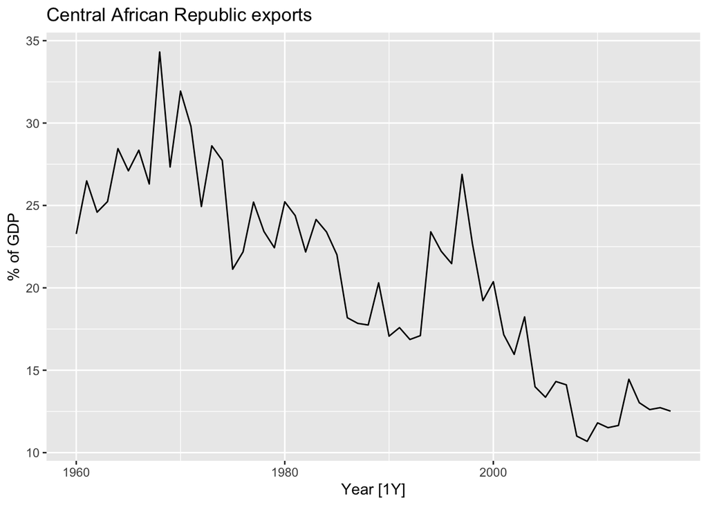

```r
global_economy |>
  filter(Code == "CAF") |>
  autoplot(Exports) +
  labs(title="Central African Republic exports",
       y="% of GDP")
```

Figure 9.13: Exports of the Central African Republic as a percentage of GDP.

1. 시계열 그래프에서 비정상성이 관찰됨 → 전반적인 하락 추세 존재

1994년의 일시적 개선은 → 군부를 전복한 새 정부의 집권에 따른 효과 → 이후 정세 불안으로 다시 경제 하락

2. 분산 변화는 없음 → Box-Cox 변환 불필요
3. 비정상성 보정을 위해 → 1차 차분 수행 → 차분된 데이터는 Figure 9.14에 시각화됨

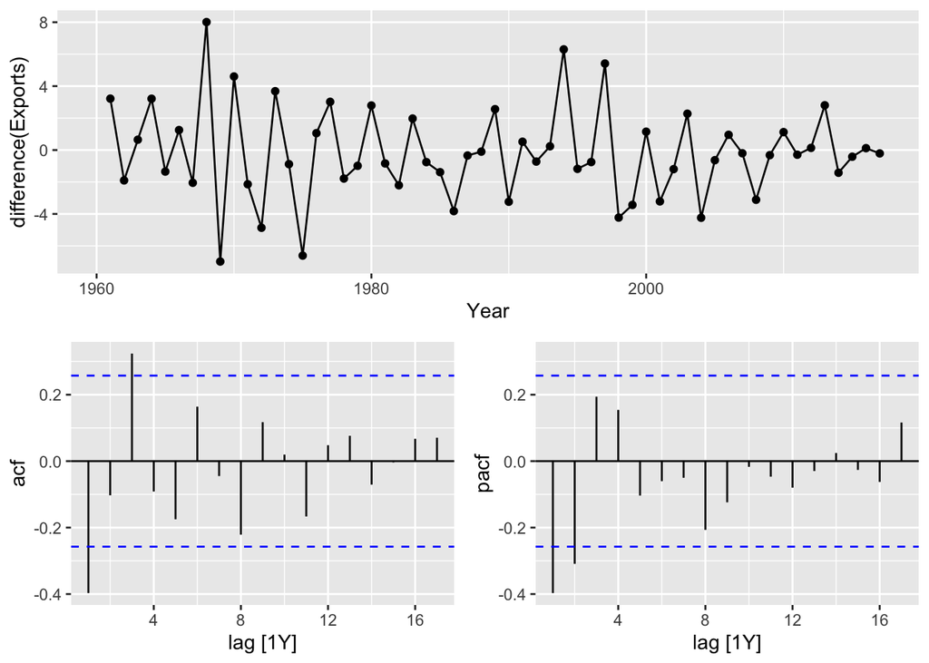

```r
global_economy |>
  filter(Code == "CAF") |>
  gg_tsdisplay(difference(Exports), plot_type='partial')
```

Figure 9.14: Time plot and ACF and PACF plots for the differenced Central African Republic Exports.

4. PACF 분석 결과 → AR(2) 형태 제안 → 후보 모델 ①: ARIMA(2,1,0)

ACF 분석 결과 → MA(3) 형태 제안 → 후보 모델 ②: ARIMA(0,1,3)

5. 두 모델 모두 적합한 뒤, → 자동 모델 선택도 병행 수행:

기본 stepwise 방법

더 넓은 모형 공간을 탐색하는 정밀 탐색 방법

```r
caf_fit <- global_economy |>
  filter(Code == "CAF") |>
  model(arima210 = ARIMA(Exports ~ pdq(2,1,0)),
        arima013 = ARIMA(Exports ~ pdq(0,1,3)),
        stepwise = ARIMA(Exports),
        search = ARIMA(Exports, stepwise=FALSE))

caf_fit |> pivot_longer(!Country, names_to = "Model name",
                         values_to = "Orders")
```

```
## # A mable: 4 x 3
## # Key:     Country, Model name [4]
##   Country                  `Model name`         Orders
##   <fct>                    <chr>               <model>
## 1 Central African Republic arima210     <ARIMA(2,1,0)>
## 2 Central African Republic arima013     <ARIMA(0,1,3)>
## 3 Central African Republic stepwise     <ARIMA(2,1,2)>
## 4 Central African Republic search       <ARIMA(3,1,0)>
```

```r
glance(caf_fit) |> arrange(AICc) |> select(.model:BIC)
```

```
## # A tibble: 4 × 6
##   .model   sigma2 log_lik   AIC  AICc   BIC
##   <chr>     <dbl>   <dbl> <dbl> <dbl> <dbl>
## 1 search     6.52   -133.  274.  275.  282.
## 2 arima210   6.71   -134.  275.  275.  281.
## 3 arima013   6.54   -133.  274.  275.  282.
## 4 stepwise   6.42   -132.  274.  275.  284.
```

ARIMA 모델 비교 결과 요약

- 4개 모델의 AICc 값은 거의 유사
- 가장 낮은 AICc: → ARIMA(3,1,0) (정밀 탐색 결과)
- 그 다음: → ARIMA(2,1,0), ARIMA(0,1,3) (ACF/PACF 기반으로 추정한 후보 모델)
- 자동 stepwise 방법은 → ARIMA(2,1,2) 선택 → 4개 중 AICc 가장 높음
6. ARIMA(3,1,0) 모델의 잔차 ACF 플롯 분석 결과: → 모든 자기상관 계수가 임계값 안에 있음

✅ 이는 잔차가 white noise처럼 보인다는 것을 의미 → 모델이 데이터를 잘 설명하고 있음

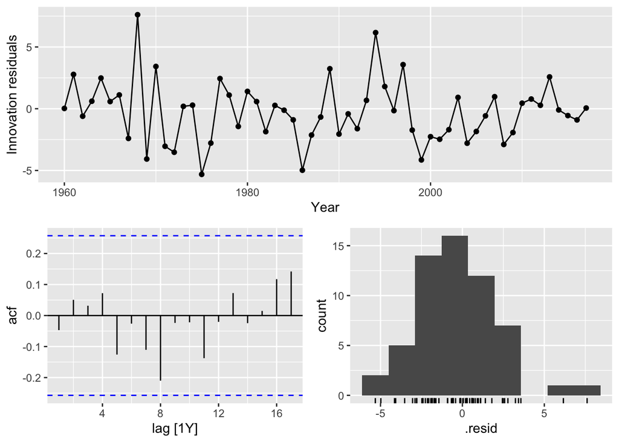

```r
caf_fit |>
  select(search) |>
  gg_tsresiduals()
```

Figure 9.15: Residual plots for the ARIMA(3,1,0) model.

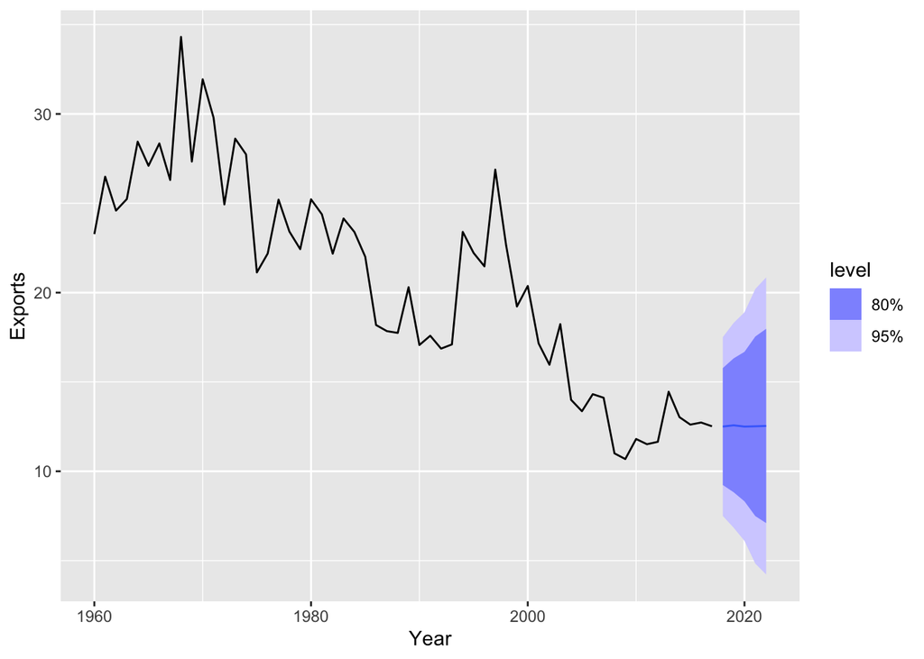

```r
caf_fit |>
  forecast(h=5) |>
  filter(.model=='search') |>
  autoplot(global_economy)
```

Figure 9.16: Forecasts for the Central African Republic Exports.

예측 결과 요약 * **평균 예측값(점 예측)**은 → **랜덤 워크 모델 (ARIMA(0,1,0))**과 거의 유사함

- 하지만 AR/MA 항을 포함한 모델은 → **예측 구간(신뢰구간)**이 훨씬 더 좁음

### Understanding constants in R

#### 1. ARIMA 모델의 두 가지 표현식

일반 형태 (fable 기준):

$$(1 - \phi_1 B - \cdots - \phi_p B^p)(1 -
B)^d y_t = c + (1 + \theta_1 B + \cdots + \theta_q B^q)\varepsilon_t
\tag{9.3}$$

대안 표현 (다른 R 패키지에서 사용):

$$(1 - \phi_1 B - \cdots - \phi_p B^p)(1 -
B)^d \left(y_t - \frac{\mu t^d}{d!} \right) = (1 + \theta_1 B + \cdots +
\theta_q B^q)\varepsilon_t \tag{9.4}$$

- 이때
  $$c = \mu(1 - \phi_1 - \cdots -
  \phi_p)$$
- $\mu$는 차분된 시계열 $[(1 - B)^d y_t]$의 평균

#### 2. 상수항 의미 및 적용 조건

- 상수 포함 여부는 **ARIMA()가 자동 결정**
- 조건:
  - $d = 0$ 또는 $d = 1$이면 AICc가 개선될 경우 포함
  - $d > 1$이면 항상 **제외**  
    → 고차 다항 추세는 예측에 **위험**함

상수항 강제 포함 ARIMA(y ~ 1 + pdq(…))

상수항 제거 ARIMA(y ~ 0 + pdq(…))

### Plotting the characteristic roots

ARIMA 모델의 정상성과 가역성 조건은 AR(ϕ)과 MA(θ) 다항식의 **복소수 근(roots)**이 **단위원(unit circle)** 바깥에 있어야 만족된다.

ARIMA 식 (9.3)을 다음과 같이 정리할 수 있다:

$$\phi(B)(1 - B)^d y_t = c + \theta(B)\varepsilon_t$$

- $\phi(B) = 1 - \phi_1 B - \cdots - \phi_p B^p$
- $\theta(B) = 1 + \theta_1 B + \cdots + \theta_q B^q$

####. 정상성 & 가역성 조건

- **Stationarity**: $\phi(B)$의 근들이 **단위원 외부**에 존재해야 함
- **Invertibility**: $\theta(B)$의 근들도 **단위원 외부**에 있어야 함

따라서, **역근(inverse roots)**을 시각화하면,  
→ **정상적이면 단위원 내부에 위치**하게 된다.

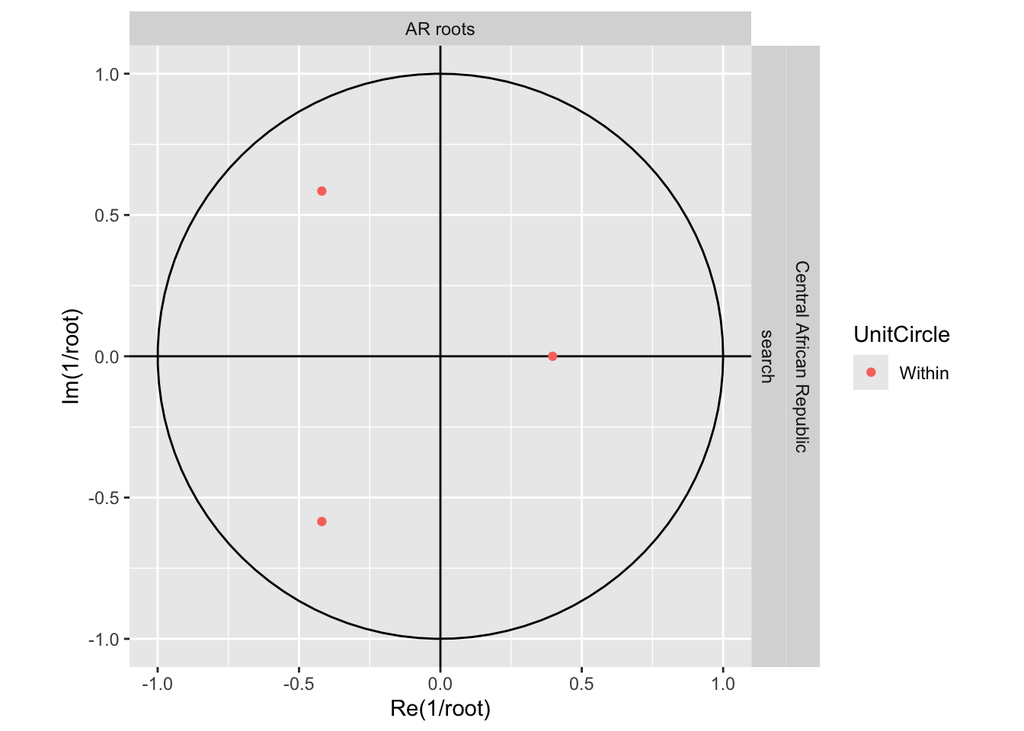

```r
gg_arma(caf_fit |> select(Country, search))
```

Figure 9.17: Inverse characteristic roots for the ARIMA(3,1,0) model fitted to the Central African Republic Exports.

ARIMA 특성근 요약

- 주황색 점 3개는 AR 다항식 $\phi(B)$의 역근 (inverse roots) → 모두 단위원 내부에 있음 ✅ → 정상성(stationarity) 만족
- fable::ARIMA()는 항상:
  - 정상성과 가역성 조건을 만족하는 모델만 반환함
  - 단위원에 너무 가까운 근도 피함 → 수치적으로 불안정하며 예측 성능이 낮을 수 있음
- 📉 주의사항: AICc가 더 낮은 모델이 존재하더라도, → 근이 단위원에 너무 가까우면 사용 비추천